# HPMT 5214 - Assignment 4

Evan Munro

3/08/2021

# **Prompt**

Answer to the Question 11 of Chapter 4 on Page 171 in the textbook “Introduction to Statistical Learning” [Note: answer to all parts except part (g)]. This question asks you to use the dataset “Auto” which is part of “ISLR” library. As instructed in the class, in order to load the data within a library, you should first load the library.

## **11.**

#### In this problem, you will develop a model to predict whether a given car gets high or low gas mileage based on the Auto data set.

```r
library(ISLR)
library(dplyr)
library(e1071)
library(MASS)
data(Auto)
```

### **a)**

#### Create a binary variable, `mpg01`, that contains a 1 if mpg contains a value above its median, and a 0 if mpg contains a value below its median. You can compute the median using the `median()` function. Note you may find it helpful to use the `data.frame()` function to create a single data set containing both `mpg01` and the other Auto variables.

```r
auto = data.frame(Auto)
str(auto)
```

```
## 'data.frame':    392 obs. of  9 variables:
##  $ mpg         : num  18 15 18 16 17 15 14 14 14 15 ...
##  $ cylinders   : num  8 8 8 8 8 8 8 8 8 8 ...
##  $ displacement: num  307 350 318 304 302 429 454 440 455 390 ...
##  $ horsepower  : num  130 165 150 150 140 198 220 215 225 190 ...
##  $ weight      : num  3504 3693 3436 3433 3449 ...
##  $ acceleration: num  12 11.5 11 12 10.5 10 9 8.5 10 8.5 ...
##  $ year        : num  70 70 70 70 70 70 70 70 70 70 ...
##  $ origin      : num  1 1 1 1 1 1 1 1 1 1 ...
##  $ name        : Factor w/ 304 levels "amc ambassador brougham",..: 49 36 231 14 161 141 54 223 241 2 ...
```

```r
# origin should be a categorical variable
auto$origin = as.factor(auto$origin)
med = median(auto$mpg)
mpg01 = rep(0, nrow(auto))
mpg01[auto$mpg > med] = 1
auto = data.frame(auto, mpg01)
```

### **b)**

#### Explore the data graphically in order to investigate the association between `mpg01` and the other features. Which of the other features seem most likely to be useful in predicting `mpg01`? Scatterplots and boxplots may be useful tools to answer this question. Describe your findings.

```r
str(auto)
```

```
## 'data.frame':    392 obs. of  10 variables:
##  $ mpg         : num  18 15 18 16 17 15 14 14 14 15 ...
##  $ cylinders   : num  8 8 8 8 8 8 8 8 8 8 ...
##  $ displacement: num  307 350 318 304 302 429 454 440 455 390 ...
##  $ horsepower  : num  130 165 150 150 140 198 220 215 225 190 ...
##  $ weight      : num  3504 3693 3436 3433 3449 ...
##  $ acceleration: num  12 11.5 11 12 10.5 10 9 8.5 10 8.5 ...
##  $ year        : num  70 70 70 70 70 70 70 70 70 70 ...
##  $ origin      : Factor w/ 3 levels "1","2","3": 1 1 1 1 1 1 1 1 1 1 ...
##  $ name        : Factor w/ 304 levels "amc ambassador brougham",..: 49 36 231 14 161 141 54 223 241 2 ...
##  $ mpg01       : num  0 0 0 0 0 0 0 0 0 0 ...
```

```r
cor(auto[,-which(names(auto) %in% c("name", "origin"))])
```

```
##                     mpg  cylinders displacement horsepower     weight
## mpg           1.0000000 -0.7776175   -0.8051269 -0.7784268 -0.8322442
## cylinders    -0.7776175  1.0000000    0.9508233  0.8429834  0.8975273
## displacement -0.8051269  0.9508233    1.0000000  0.8972570  0.9329944
## horsepower   -0.7784268  0.8429834    0.8972570  1.0000000  0.8645377
## weight       -0.8322442  0.8975273    0.9329944  0.8645377  1.0000000
## acceleration  0.4233285 -0.5046834   -0.5438005 -0.6891955 -0.4168392
## year          0.5805410 -0.3456474   -0.3698552 -0.4163615 -0.3091199
## mpg01         0.8369392 -0.7591939   -0.7534766 -0.6670526 -0.7577566
##              acceleration       year      mpg01
## mpg             0.4233285  0.5805410  0.8369392
## cylinders      -0.5046834 -0.3456474 -0.7591939
## displacement   -0.5438005 -0.3698552 -0.7534766
## horsepower     -0.6891955 -0.4163615 -0.6670526
## weight         -0.4168392 -0.3091199 -0.7577566
## acceleration    1.0000000  0.2903161  0.3468215
## year            0.2903161  1.0000000  0.4299042
## mpg01           0.3468215  0.4299042  1.0000000
```

Cylinders, displacement, horsepower, and weight have absolute correlations > 0.5. Mpg is ignored because it was used to make the new variable mpg01.

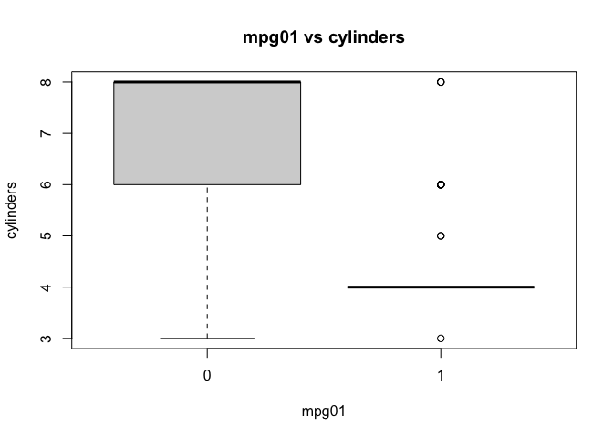

```r
attach(auto)
boxplot(cylinders ~ mpg01, data = auto, main = "mpg01 vs cylinders")
```

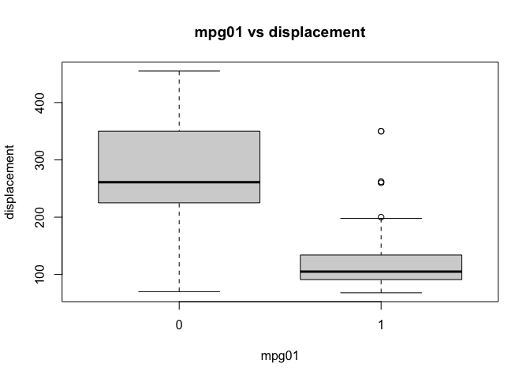

```r
boxplot(displacement ~ mpg01, data = auto, main = "mpg01 vs displacement")
```

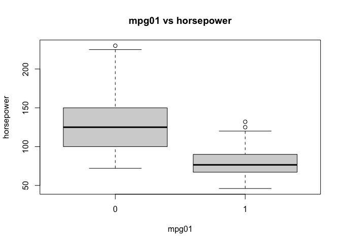

```r
boxplot(horsepower ~ mpg01, data = auto, main = "mpg01 vs horsepower")
```

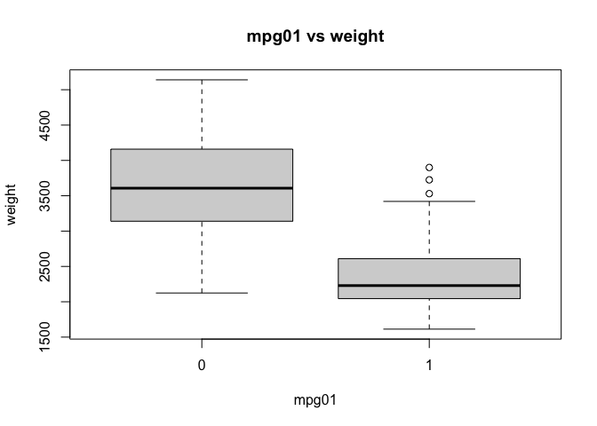

```r
boxplot(weight ~ mpg01, data = auto, main = "mpg01 vs weight")
```

It seems that cylinders, displacement, horsepower, and weight are the variables most likely to be useful in predicting `mpg01`.

### **c)**

#### Split the data into a training set and a test set.

```r
set.seed(118)
trainIndices = sample(nrow(auto), nrow(auto)*0.8)
mpg01_train = auto[trainIndices,]
mpg01_test = auto[-trainIndices,]
mpg01_pred = mpg01[-trainIndices]
```

### **d)**

#### Perform LDA on the training data in order to predict `mpg01` using the variables that seemed most associated with `mpg01` in (b). What is the test error of the model obtained?

```r
mpg_lda = lda(mpg01 ~ cylinders + displacement + horsepower + weight, data = mpg01_train)
lda_pred = predict(mpg_lda, mpg01_test)
lda_class = lda_pred$class
table(lda_class, mpg01_pred)
```

```
##          mpg01_pred
## lda_class  0  1
##         0 37  4
##         1  6 32
```

```r
mean(lda_class != mpg01_pred)
```

```
## [1] 0.1265823
```

The test error rate for the LDA model is 12.66%.

### **e)**

#### Perform QDA on the training data in order to predict `mpg01` using the variables that seemed most associated with `mpg01` in (b). What is the test error of the model obtained?

```r
mpg_qda = qda(mpg01 ~ cylinders + displacement + horsepower + weight, data = mpg01_train)
qda_pred = predict(mpg_qda, mpg01_test)
qda_class = qda_pred$class
table(qda_class, mpg01_pred)
```

```
##          mpg01_pred
## qda_class  0  1
##         0 37  5
##         1  6 31
```

```r
mean(qda_class != mpg01_pred)
```

```
## [1] 0.1392405
```

The test error rate for the QDA model is 13.92%.

### **f)**

#### Perform logistic regression on the training data in order to predict `mpg01` using the variables that seemed most associated with `mpg01` in (b). What is the test error of the model obtained?

```r
mpg_glm = glm(mpg01 ~ cylinders + displacement + horsepower + weight, data = mpg01_train, family = binomial)
summary(mpg_glm)
```

```
##
## Call:
## glm(formula = mpg01 ~ cylinders + displacement + horsepower +
##     weight, family = binomial, data = mpg01_train)
##
## Deviance Residuals:
##     Min       1Q   Median       3Q      Max
## -2.5841  -0.1832   0.1137   0.3466   3.4245
##
## Coefficients:
##                Estimate Std. Error z value Pr(>|z|)
## (Intercept)  14.0748340  2.0931252   6.724 1.76e-11 ***
## cylinders    -0.5466160  0.4093871  -1.335  0.18181
## displacement -0.0018634  0.0096597  -0.193  0.84704
## horsepower   -0.0402005  0.0169969  -2.365  0.01802 *
## weight       -0.0025348  0.0008057  -3.146  0.00165 **
## ---
## Signif. codes:  0 '***' 0.001 '**' 0.01 '*' 0.05 '.' 0.1 ' ' 1
##
## (Dispersion parameter for binomial family taken to be 1)
##
##     Null deviance: 433.75  on 312  degrees of freedom
## Residual deviance: 156.79  on 308  degrees of freedom
## AIC: 166.79
##
## Number of Fisher Scoring iterations: 7
```

```r
glm_probs = predict(mpg_glm, mpg01_test, type = "response")
glm_pred=rep(0, nrow(mpg01_test))
glm_pred[glm_probs > 0.5] = 1
table(glm_pred, mpg01_pred)
```

```
##         mpg01_pred
## glm_pred  0  1
##        0 37  4
##        1  6 32
```

```r
mean(glm_pred != mpg01_pred)
```

```
## [1] 0.1265823
```

The test error rate for the logistic regression model is 12.66%, which is the same error rate that the LDA model had, but all of the models had very similar results.